# Part 2 Data

## 2.1 Financial Data

For our financial data, we decided to use minute-by-minute prices for broad market indices. Since the actual indices do not update their prices that often, we had to take proxies under the form of ETFs that track them. These ETFs exist to provide investors with direct exposure to whole markets and have very small to no deviations to the corresponding index. Our 3 markets of analysis are: SPY to track the S&P500 (note that this ETF has a very large trading volume relative to the others), VGK to track the FTSE Developed Europe All Cap Index, and finally ASHR to track the CSI 300 China. We accessed this data through a free stock API, Alpha Vantage[^2]. Our timeframe starts on the first of January 2014 and goes to the 7th of May 2025.

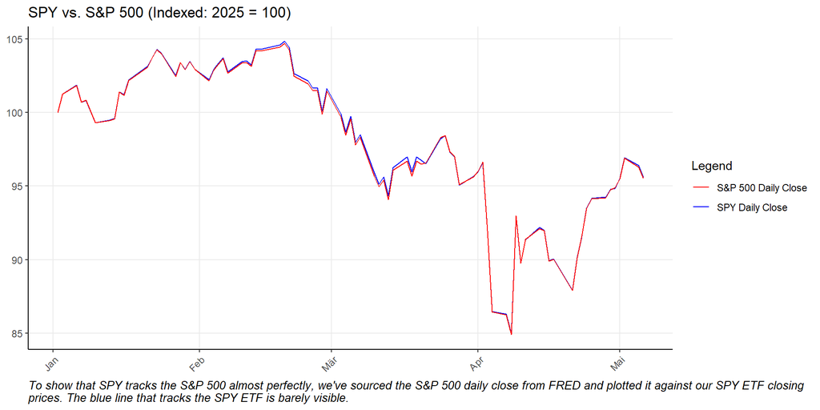

Figure 2.1: SPY vs. S&P 500 (Indexed: 2025 = 100)

We had to transform this data to get our main variable of interest, Average Hourly Volatility (AHV). Note that this is *realized* market volatility. We did so using the following formula:
$$\begin{aligned}
AHV_t = \frac{1}{N}&\sum_{i=1}^N(\Delta p_{t,i})^2
\end{aligned}$$
Where $\Delta p_t$ is the difference in price (open - close), $i$ represents every minute, $t$ represents an hour, and $N$ is the total number of minutes in each hour.

Ultimately, we compute the AHV for each open market hour since 2014. Note that the first hour is from 9:30 am to 10:00 am since the market opens on a half-hour but closes at 4:00 pm. Plotting this data, we observe that the last few months (corresponding to Donald Trump’s first 100 days in office) display unprecedented levels of volatility which have reached, and even surpassed, levels seen during the COVID-19 pandemic.

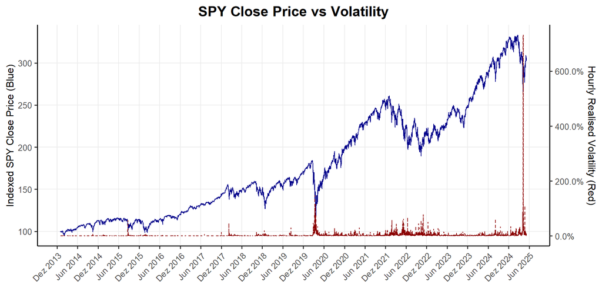

Figure 2.2: SPY Close Price vs Volatility

## 2.2 Political Data

We have two types of data for Trump’s posts, Tweets & “Truths” (from Truth Social). The Tweets are sourced from Kaggle (Shantanu (n.d.)) and stop in January 2021, seen as Trump was then banned. Due to this, we have a gap in this data going until February 2022, when he first posted on his own new platform. All Truth Social posts were pulled from “trumpstruth.org”, a webpage that aims to conserve all his posts. Note that we have had to use web-scrapping methods in order to download all these posts in a dataset.

A big problem we had in our analysis was what to do with social media posts which appeared outside market hours. We first decided to simply ignore them, but it turned out to remove such a large amount of observations that it severely limited our analysis. We finally decided to push all the social media information outside market hours to the next open hour. This comes as a critical assumption[^3].

Since our financial data is hourly, we aggregate the social data by hour as well and construct multiple variables from this. These variables include a dummy for whether there was a post in a particular hour ($TweetDummy$), the number of posts in an hour ($TweetCount$), and counts for mentions of certain words ($Tariff$, $Trade$, & $China$).

Furthermore, we applied simple sentiment analysis algorithms in order to extract emotions and proportions for the amount of “positive” and “negative” words from the posts. We however ended up not including these in our final analyses as results were not particularly interesting. Details on all our data management procedures as well as the final dataset can be found in the GitHub repository.

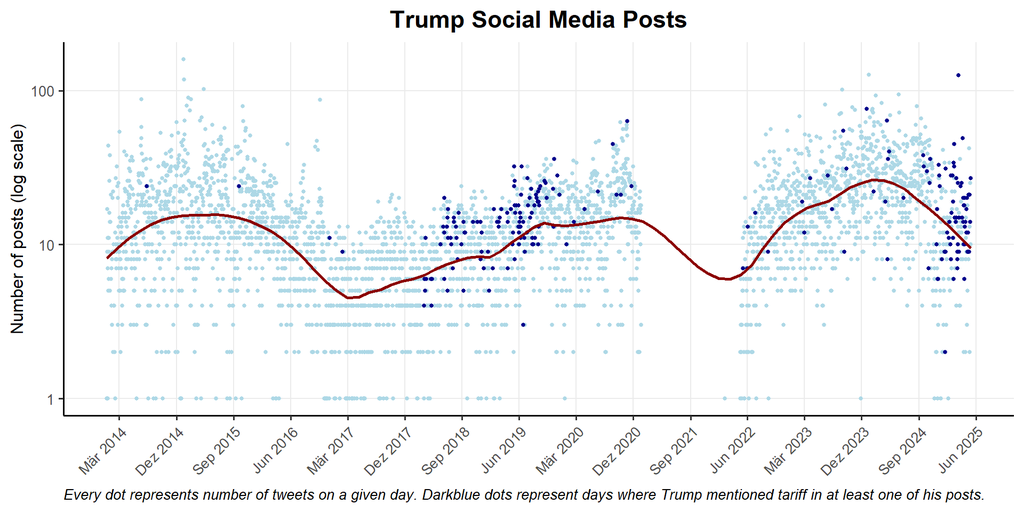

Figure 2.3: Poster in Chief: Number of Social Media Posts with Mentions of Tariff

## 2.3 Final Dataframe

Our final Dataframe is quite wide and contains the following Variables:

| Variable | Description |
| --- | --- |
| _vol | The average hourly reaöized volatility of given indices |
| dummy | A dummy variable, 1 if Trump posted in that hour |
| N | Number of posts in that hour |
| tariff | Mentions of tariff in that hour |
| trade | Mentions of trade in that hour |
| china | Mentions of China in that hour |
| prop | Sentiments according to NRC sentiment lexicon. Calculated as share of total sentiment and add up to 1. Positive and negative are separate measures and also add up to 1. |

And here is a look at the final Dataframe. The sentiments aren’t important for our final analysis as we didn’t get any useful results with them and decided to cut them from our final analysis:

Table 2.1:

| timestamp | SPY_vol | VGK_vol | ASHR_vol |
| --- | --- | --- | --- |
| 2025-05-06 10:00:00 | 0.0466 | 0.000731 | 5.32e-05 |
| 2025-05-06 11:00:00 | 0.0278 | 0.000217 | 3.33e-05 |
| 2025-05-06 12:00:00 | 0.0859 | 0.000468 | 3e-05 |
| 2025-05-06 13:00:00 | 0.0457 | 0.000457 | 3.26e-05 |
| 2025-05-06 14:00:00 | 0.0336 | 0.000224 | 2.24e-05 |
| 2025-05-06 15:00:00 | 0.0517 | 0.000295 | 2.03e-05 |

Table 2.1:

| dummy | N | tariff | trade | china |
| --- | --- | --- | --- | --- |
| 0 | 0 | 0 | 0 | 0 |
| 0 | 0 | 0 | 0 | 0 |
| 1 | 3 | 0 | 2 | 0 |
| 1 | 5 | 0 | 0 | 0 |
| 1 | 1 | 0 | 0 | 0 |
| 0 | 0 | 0 | 0 | 0 |

Table 2.1:

| prop_anger | prop_anticipation | prop_disgust | prop_fear | prop_joy |
| --- | --- | --- | --- | --- |
| 0 | 0 | 0 | 0 | 0 |
| 0 | 0 | 0 | 0 | 0 |
| 0.0909 | 0.0455 | 0.0909 | 0.227 | 0 |
| 0.087 | 0.087 | 0 | 0.13 | 0.13 |
| 0 | 0 | 0 | 0 | 0 |
| 0 | 0 | 0 | 0 | 0 |

Table 2.1:

| prop_sadness | prop_surprise | prop_trust | prop_negative | prop_positive |
| --- | --- | --- | --- | --- |
| 0 | 0 | 0 | 0 | 0 |
| 0 | 0 | 0 | 0 | 0 |
| 0.0455 | 0.136 | 0.364 | 0.556 | 0.444 |
| 0.0435 | 0.087 | 0.435 | 0.176 | 0.824 |
| 0 | 0 | 0 | 0 | 0 |
| 0 | 0 | 0 | 0 | 0 |

### References

Shantanu, R. (n.d.). *Donald Trump Tweets Dataset*. https://www.kaggle.com/datasets/codebreaker619/donald-trump-tweets-dataset.

[^2]: https://www.alphavantage.co/
[^3]: For instance, if Trump tweets on Good Friday (market holiday), then the market will only react to this new information on Monday at 9:30 am.